# Fauna community analysis

Lydia White & Nico Henry

2025-05-24

## Set up our environment

### Load libraries

First we load libraries (which you should already have installed), we will also need vegan for doing multivariate analysis

```r
library(tidyverse)
library(googlesheets4)
library(vegan)
```

## Abundance

### Import data

```r
gs4_deauth()

#abundance <- read_sheet("1AyJXPaJZMl1a4vogToBIMSoPDGY2wBq8K3k8g9EptRc" , sheet = "benthos_abundance_per sample") #2025

abundance <- read_sheet("1STH7IQobfCN5dumGnuSGqDiIoqHk1IkAUg3TTRu0pVc" , sheet = "benthos_abundance_per sample") #2023
```

### Visualise differences in fauna abundance

Boxplot of total abundance per sample for different sites

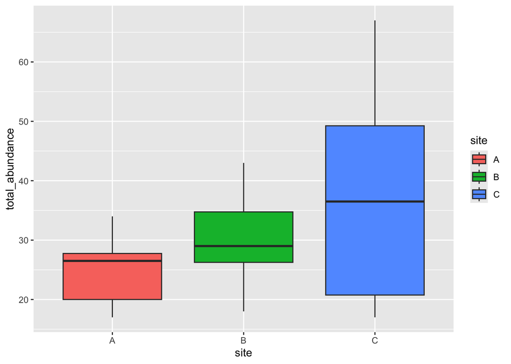

```r
ggplot(abundance, aes(x=site, y= total_abundance, fill = site)) +
  geom_boxplot()
```

We can tidy up the plot a bit, we edit the y axis label and remove the legend

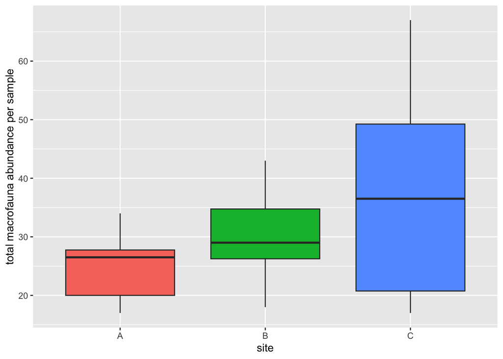

```r
ggplot(abundance, aes(x=site, y=total_abundance, fill=site)) +
  geom_boxplot() +
  ylab("total macrofauna abundance per sample") +
  theme(legend.position="none")
```

You can do the same for species richness, but we need to seperate the species abundance matrix and site information into 2 different dataframes.

R doesn’t recognise empty spaces from the excel file, we need to tell it they are zeros. So we replace NA with zero on all numeric columns.

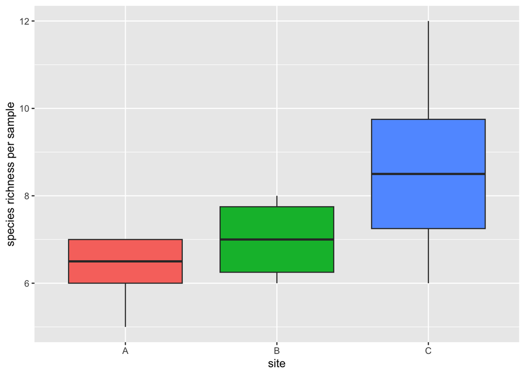

```r
species_matrix <- abundance %>% select (-site, -date, -replicate, -treatment, -total_abundance, -abundance_per_m2) %>% data.frame(row.names = "sample")

environmental_table <- abundance %>% select (sample, site, date, replicate, treatment, total_abundance, abundance_per_m2)

species_matrix <- mutate_all(species_matrix, ~as.numeric(replace_na(.,0)))

richness <- specnumber(species_matrix)

richness <- tibble(sample = names(richness), species_richness = richness) %>%
  inner_join( environmental_table)

ggplot(richness, aes(x=site, y=species_richness, fill=site)) +
  geom_boxplot() +
  ylab("species richness per sample") +
  theme(legend.position="none")
```

### Test differences with models

One way ANOVA

```r
anova1 <- aov(species_richness~ site, data = richness)
summary(anova1)
```

```
##             Df Sum Sq Mean Sq F value Pr(>F)
## site         2  17.33   8.667   4.239 0.0347 *
## Residuals   15  30.67   2.044
## ---
## Signif. codes:  0 '***' 0.001 '**' 0.01 '*' 0.05 '.' 0.1 ' ' 1
```

Check assumptions etc…

```r
# write script here (copy and paste from previous scripts and change variable names etc)
```

### Multivariate analysis

Standardise from absolute abundance to relative abundance

```r
species_matrix_rel <-
  decostand(species_matrix, method = "total")
```

#### NMDS plot

Calculate distance matrix and plot NMDS.

```r
species_matrix_distmat <-
  vegdist(species_matrix_rel, method = "bray")

species_matrix_NMDS <-
  metaMDS(species_matrix_distmat,
          distance = "bray",
          k = 2,
          maxit = 999,
          trymax = 500,
          wascores = TRUE)
```

```
## *** Best solution repeated 1 times
```

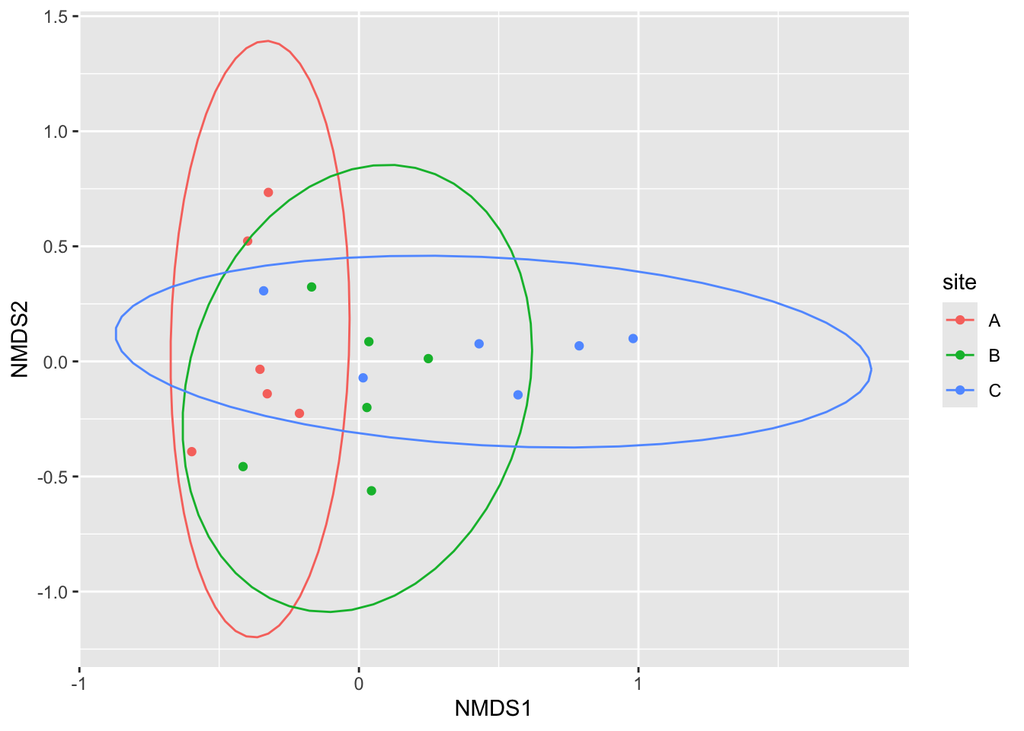

```r
scores <- as_tibble(scores(species_matrix_NMDS), rownames = "sample")

final <- inner_join(environmental_table, scores)

ggplot(final, aes(x= NMDS1, y= NMDS2, colour = site)) +
  geom_point( ) +
  stat_ellipse()
```

#### PERMANOVA

We can do a PERMANOVA, analogous to a ANOVA, but for multivariate data, to see if communities differ between site. We need to check the assumptions of homogeneous dispersion between groups before doing a PERMANOVA. p < 0.05 means that they are not homogeneous.

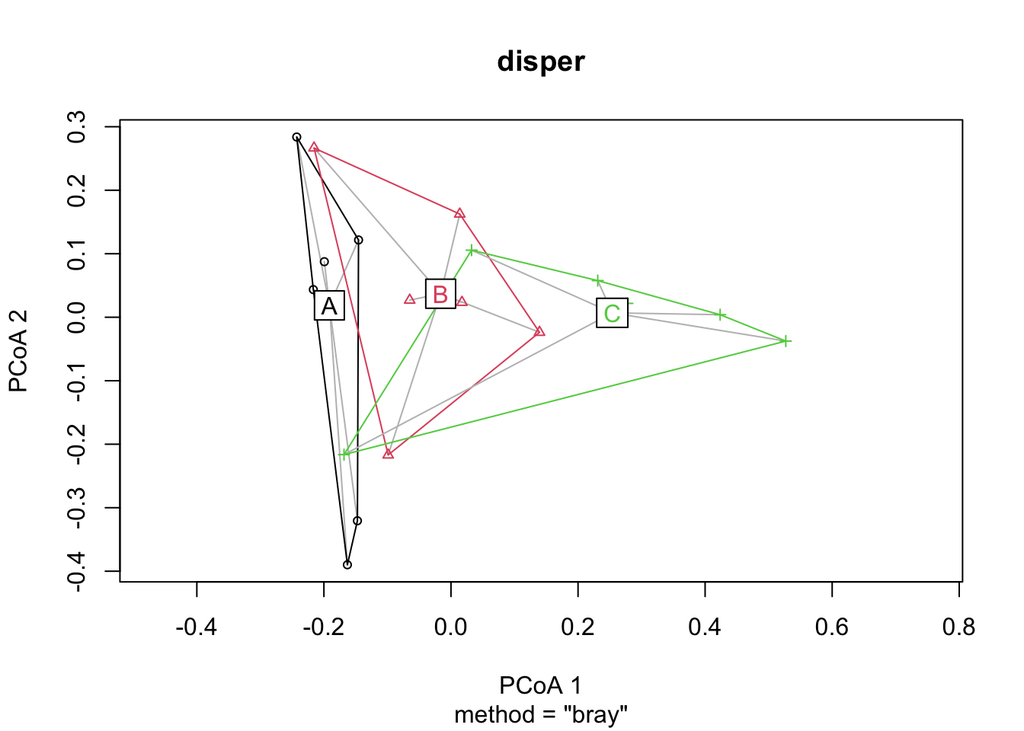

```r
disper <- betadisper(species_matrix_distmat, environmental_table$site)
plot(disper)
```

```r
anova(disper)
```

```
## Analysis of Variance Table
##
## Response: Distances
##           Df   Sum Sq   Mean Sq F value Pr(>F)
## Groups     2 0.000858 0.0004289  0.0358 0.9649
## Residuals 15 0.179446 0.0119631
```

then we run the PERMANOVA.

```r
adonis2(species_matrix_rel ~ site, data = environmental_table, permutations = 999)
```

```
## Permutation test for adonis under reduced model
## Permutation: free
## Number of permutations: 999
##
## adonis2(formula = species_matrix_rel ~ site, data = environmental_table, permutations = 999)
##          Df SumOfSqs      R2      F Pr(>F)
## Model     2  0.59738 0.27336 2.8215  0.012 *
## Residual 15  1.58791 0.72664
## Total    17  2.18529 1.00000
## ---
## Signif. codes:  0 '***' 0.001 '**' 0.01 '*' 0.05 '.' 0.1 ' ' 1
```

Then pairwise tests to see which groups differ. You can load a special function for this. See for more info: https://github.com/pmartinezarbizu/pairwiseAdonis

```r
source(here::here("R", "pairwise_adonis2.R"))

pairwise.adonis2 (species_matrix_rel ~ site, data = environmental_table, permutations = 999)
```

```
## $parent_call
## [1] "species_matrix_rel ~ site , strata = Null , permutations 999"
##
## $A_vs_B
##          Df SumOfSqs      R2      F Pr(>F)
## Model     1  0.12792 0.11081 1.2462  0.262
## Residual 10  1.02648 0.88919
## Total    11  1.15440 1.00000
##
## $A_vs_C
##          Df SumOfSqs      R2      F Pr(>F)
## Model     1  0.52679 0.32494 4.8135  0.008 **
## Residual 10  1.09441 0.67506
## Total    11  1.62120 1.00000
## ---
## Signif. codes:  0 '***' 0.001 '**' 0.01 '*' 0.05 '.' 0.1 ' ' 1
##
## $B_vs_C
##          Df SumOfSqs      R2      F Pr(>F)
## Model     1  0.24136 0.18619 2.2879  0.094 .
## Residual 10  1.05493 0.81381
## Total    11  1.29629 1.00000
## ---
## Signif. codes:  0 '***' 0.001 '**' 0.01 '*' 0.05 '.' 0.1 ' ' 1
##
## attr(,"class")
## [1] "pwadstrata" "list"
```

You can explore which taxa contribute the most to identified differences between groups using SIMPER.

SIMPER is intended for comparisons among levels of a categorical variable, where the response matrix is expressed as a distance matrix, particularly the Bray-Curtis dissimilarity measure.

More information about how to interpret SIMPER results can be found here:

https://uw.pressbooks.pub/appliedmultivariatestatistics/chapter/simper/

```r
test<- with(environmental_table, simper(species_matrix_rel, site))
summary(test)
```

```
##
## Contrast: A_B
##
##                       average      sd   ratio     ava     avb cumsum     p
## Hydrobia.sp.          0.11125 0.07400 1.50340 0.37160 0.35470  0.251 0.366
## Macoma.balthica       0.06801 0.05077 1.33950 0.17440 0.11810  0.404 0.449
## Ostracoda             0.05099 0.04570 1.11580 0.00980 0.10710  0.519 0.827
## Hediste.diversicolor  0.04016 0.02816 1.42640 0.13440 0.12000  0.609 0.511
## Oligochaeta           0.03685 0.02739 1.34520 0.14050 0.15480  0.692 0.221
## Marenzelleria         0.02898 0.03257 0.88970 0.06510 0.03080  0.757 0.304
## Potamopyrgus          0.02220 0.03624 0.61260 0.04440 0.00000  0.807 0.800
## Nematoda              0.01991 0.02993 0.66520 0.00000 0.03980  0.852 0.992
## Chironomidae          0.01682 0.01376 1.22230 0.00000 0.03360  0.890 0.613
## Amphibalanus          0.00926 0.02100 0.44100 0.00000 0.01850  0.911 0.001 ***
## Cerastoderma          0.00840 0.01353 0.62100 0.01680 0.00000  0.930 0.001 ***
## Mya.arenaria          0.00811 0.01200 0.67540 0.01620 0.00000  0.948 0.001 ***
## Gammarus              0.00669 0.01076 0.62180 0.00620 0.00930  0.963 0.358
## Argyroneta.aquatica   0.00490 0.01112 0.44100 0.00980 0.00000  0.974 0.001 ***
## Sinelobus             0.00463 0.01050 0.44100 0.00000 0.00930  0.985 0.426
## Insect..unidentified. 0.00427 0.00687 0.62100 0.00600 0.00390  0.995 0.578
## Mysis                 0.00245 0.00556 0.44100 0.00490 0.00000  1.000 0.001 ***
## Cyanophthalma         0.00000 0.00000     NaN 0.00000 0.00000  1.000    NA
## Lymnaeidae            0.00000 0.00000     NaN 0.00000 0.00000  1.000    NA
## Halicryptus           0.00000 0.00000     NaN 0.00000 0.00000  1.000    NA
## Manayunkia.aestuarina 0.00000 0.00000     NaN 0.00000 0.00000  1.000    NA
## ---
## Signif. codes:  0 '***' 0.001 '**' 0.01 '*' 0.05 '.' 0.1 ' ' 1
##
## Contrast: A_C
##
##                       average      sd   ratio     ava     avb cumsum     p
## Hydrobia.sp.          0.12168 0.07540 1.61380 0.37160 0.19684  0.211 0.116
## Nematoda              0.10034 0.08486 1.18240 0.00000 0.20068  0.386 0.013 *
## Ostracoda             0.07691 0.05306 1.44970 0.00980 0.15901  0.519 0.015 *
## Macoma.balthica       0.07595 0.06005 1.26470 0.17440 0.07814  0.651 0.139
## Hediste.diversicolor  0.03763 0.02573 1.46240 0.13440 0.06715  0.717 0.668
## Potamopyrgus          0.03473 0.03329 1.04300 0.04440 0.05529  0.777 0.179
## Marenzelleria         0.02912 0.03303 0.88190 0.06510 0.02783  0.827 0.259
## Oligochaeta           0.02468 0.01748 1.41190 0.14050 0.12230  0.870 0.918
## Chironomidae          0.02030 0.01984 1.02340 0.00000 0.04060  0.905 0.183
```

[output cut: 28 more lines]

```
## Amphibalanus          0.00926 0.02100 0.44100 0.01850 0.00000  0.955 0.001 ***
## Sinelobus             0.00629 0.01030 0.61040 0.00930 0.00498  0.968 0.211
## Gammarus              0.00589 0.01003 0.58730 0.00930 0.00379  0.980 0.516
## Insect..unidentified. 0.00417 0.00670 0.62210 0.00390 0.00575  0.989 0.677
## Halicryptus           0.00379 0.00859 0.44100 0.00000 0.00758  0.997 0.001 ***
## Manayunkia.aestuarina 0.00163 0.00371 0.44100 0.00000 0.00327  1.000 0.001 ***
## Argyroneta.aquatica   0.00000 0.00000     NaN 0.00000 0.00000  1.000    NA
## Cerastoderma          0.00000 0.00000     NaN 0.00000 0.00000  1.000    NA
## Lymnaeidae            0.00000 0.00000     NaN 0.00000 0.00000  1.000    NA
## Mysis                 0.00000 0.00000     NaN 0.00000 0.00000  1.000    NA
## Mya.arenaria          0.00000 0.00000     NaN 0.00000 0.00000  1.000    NA
## ---
## Signif. codes:  0 '***' 0.001 '**' 0.01 '*' 0.05 '.' 0.1 ' ' 1
## Permutation: free
## Number of permutations: 999
```

## Biomass

You could also do analysis on total biomass and multivariate analysis on biomass instead of abundance. You could copy and adapt the scripts for the biomass data.

### Import data

```r
#biomass<- read_sheet("1fXSKn11OsET_SrR7sIbFTcflnglbaVWv44oULKhfo4s" , sheet = "benthos_biomass_per sample")

biomass <- read_sheet("1STH7IQobfCN5dumGnuSGqDiIoqHk1IkAUg3TTRu0pVc", sheet = "benthos_biomass_per sample")
```

### Visualise and run models

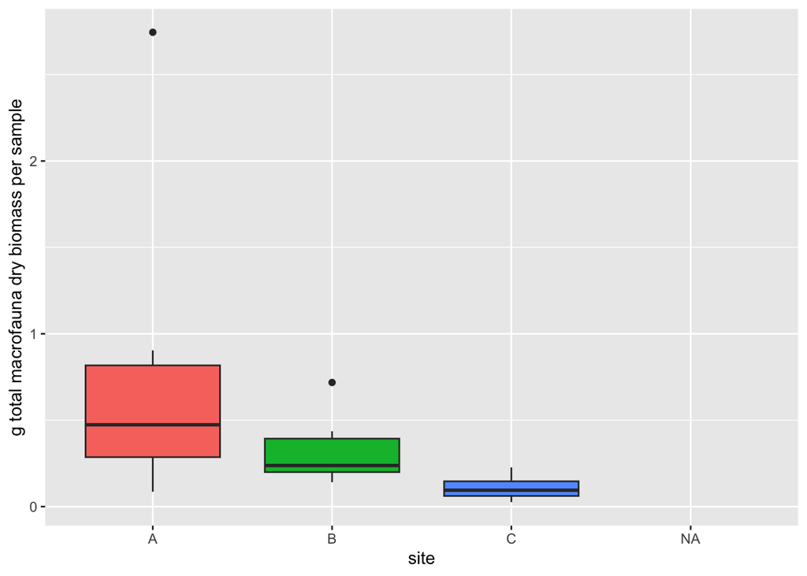

```r
ggplot(biomass, aes(x=site, y=total_biomass_dry, fill=site)) +
  geom_boxplot() +
  ylab("g total macrofauna dry biomass per sample") +
  theme(legend.position="none")
```

```r
# write scripts here (copy and paste from above and change variable names etc)
```

In order to do multivariate statistics on biomass data, individual species must be weighed which is not feasible here, due to low abundances in our samples.